# Chapter A22

# 特別な翼問題の解析

### アルフレッド・F・シュミット

## A22.1 導入

前章（A19）では、曲げの工学的理論とその合理的な修正を用いて、翼桁の解析が行われた。そこで議論されたように、通常の「梁（ビーム）」の概念から大きく外れた翼構成は、技術者に対して、梁理論への近似的および／または実験的な修正を行うか、あるいは構造の完全な解析的取り扱いを行うかの選択を迫ることになる。

本章では、航空機の翼構造に関連するいくつかの特別な問題に対する、後者のアプローチ（完全な解析的取り扱い）について説明する。すなわち、*

- Art. A22.2 - パネルカットアウト周囲の応力
- Art. A22.3 - せん断遅れ（シアラグ）問題
- Art. A22.4 - ボックスビームのカットアウト
- Art. A22.5 - 後退翼ボックスビーム

これらの問題に対する1つの解析的取り扱いを提示することに加えて、各現象の物理的性質についての議論を行う。応力問題の解決において、単一の解析手法が万能であることはないため、問題の性質を理解することは極めて重要である。解析者は、それぞれの新しい状況にアプローチする際、判断力と独創性を発揮しなければならない。

本章におけるすべての解析は、仮想単位荷重法（Chapter A7, A8）のマトリクス定式化を用いて行われており、これに関する知識があることを前提としている。

上記に挙げたような問題は、ここで詳細に研究するには複雑すぎるため、網羅的な解析は試みていない。各問題の主な特徴を際立たせるために、解析対象として選定された構造は、構成が単純であり、研究対象の現象が明確に現れるような荷重を受けるものである。外板のしわの発生、リベットや取付具の「逃げ」、応力集中などの多くの実用的な詳細事項は、目的を曖昧にしないために割愛されている。さらに、元の構造を最終的に解析されるものへとモデル化する問題については、軽く触れるにとどめ、適切な場合には追加の参考文献を引用している。

示されている解析は、外板が（適度に）薄い翼にのみ厳密に適用可能であり、そこでは「一定せん断流」の仮定が有効である。すなわち、

i - 外板はせん断応力のみを負担する  
ii - 法線（直接）応力は、外板の有効面積を統合したフランジ（桁縁材およびストリンガー）で負担される。ここで扱うすべてのケースにおいて、外板は完全に有効であると仮定された（外板の座屈応力以下の応力 - Chapter A19のArt. A19.11を参照）。

これらの問題の有用性を高めるために、解析に選定されたすべての構造は、関連するNACA（National Advisory Committee for Aeronautics）の出版物から引用されている。読者は、そこでの問題の詳細な議論、他の解析方法、および試験片の試験から得られたデータを見出すことができる。利用可能な場合には、比較のためにこれらのデータが本書で使用されている。

- もう1つの重要な特別問題である、いわゆる「ねじりによる曲げ応力」については、ここでは具体的に扱わない。Chapter A8で示されているように、そこで提示された一般的なボックスビーム解析はこの問題を網羅している（p. p. A8.24からA8.27の例題15を参照）。

## A22.2 パネルカットアウト周囲の応力

「翼や胴体のカットアウトは、航空機設計者が直面する最も厄介な問題の1つを構成している。カットアウトによって引き起こされる応力集中は局所的であるため、荷重下における単純な外板-ストリンガーパネルの挙動を解析することにより、この問題の多くの価値ある部分的な解を得ることができる」(1)**

したがって、上面にパネルカットアウトがある翼桁の場合（Fig. A22.1）、カットアウトの直ぐ周囲のセクションを、軸方向のストリンガー荷重と（桁ウェブから伝わる）縁部せん断力を受ける平板外板-ストリンガーパネルとして解析することが可能である。軸方向のストリンガー力は、カットアウト自体から十分に離れているため、曲げの工学的理論（E.T.B.）によって十分な精度で計算できる。縁部せん断流は、桁ウェブのせん断流を与える初等的な考察によって容易に計算される。

** 括弧内の数字は、章末の参考文献を参照している。

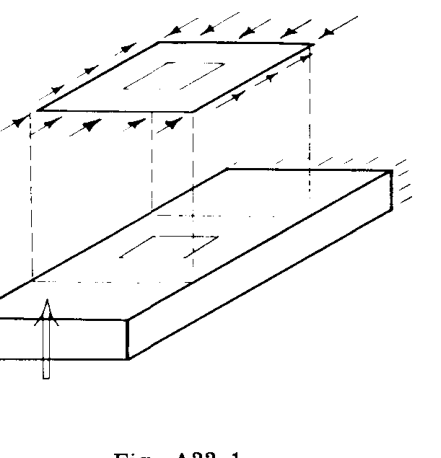

Fig. A22.1

外板-ストリンガーパネルは、一般に多数の縦方向部材（ストリンガー）を含むことがある。この多要素構造を詳細に扱うことに伴う労力は膨大であるため、適切なモデル化を行う必要がある。第一に、パネルは縦軸に対して対称であると考えられる可能性が高く、したがって半パネルのみを扱えばよい。第二に、複雑な多ストリンガー構造を、わずか3本のストリンガーを持つ構造に置き換える。Fig. A22.2に示されるように、これらのストリンガーは以下の通りである。

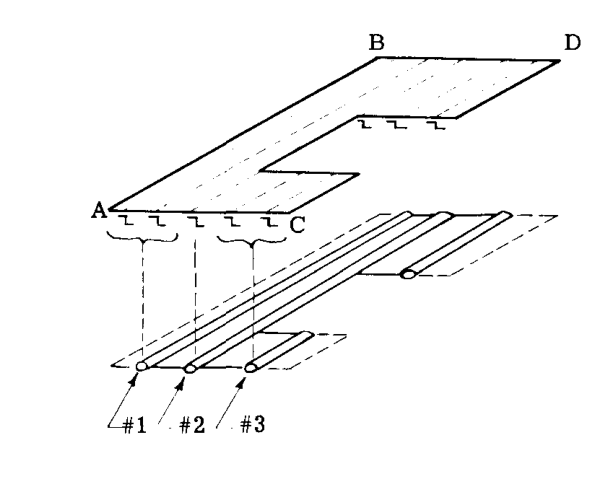

Fig. A22.2

#1 は、代替ストリンガーであり、その面積として「コーミングストリンガー」（カットアウトに隣接するストリンガー）の片側にあるすべての完全連続部材の有効面積を持ち、それが代替する材料の面積の図心に配置される。このストリンガーが発生する応力は、それが置き換える材料の平均応力となる。

#2 は、コーミングストリンガーであり、カットアウトに隣接する主要な連続ストリンガーそのものである。

#3 は、別の代替ストリンガーであり、カットアウトによって不連続となったすべての有効材料を置き換えるものである。これは、それが置き換える材料の図心に配置され、その応力はこの同じ材料の平均応力となる。*

使用される外板の厚さは、実際の構造のものと同じである。**

- ストリンガー#1と#3がそれぞれ線ABおよびCD（Fig. A22.2）に沿って配置される代替モデル化は、ねじり荷重を受けるボックスビームに関する参考文献（2）で使用された。

** 縦方向部材自体がカバーのせん断剛性に寄与する場合（外板にリベットで留められて小さな閉断面を形成する「ハット」型断面ストリンガーの場合など）、有効厚さを使用しなければならない。この点については参考文献（3）で議論されている。しかし、この文献では、せん断剛性の増加は外板厚さを増やすことではなく、パネル幅を減少させること（等価な手順）によって考慮されている。

Fig. A22.3は、モデル化されたパネルの幾何学的形状を示している。

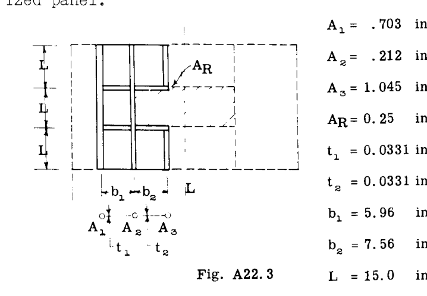

Fig. A22.3

### 解法:

Fig. A22.4は、内部一般化力（Chapter A7, Art. A7.9）の配置と番号付け、および外力を示す半パネルの展開図である。適用された軸方向応力は弦方向に一定であると仮定され、これによりストリンガー面積に比例したストリンガー荷重が与えられる。それらの合計が外力の1つである $P_2$ である。

桁ウェブから伝わる適用縁部せん断流は、一定のせん断荷重から生じるように、スパン方向に一定であると仮定された。他の荷重分布は、これらの適用せん断力をパネルごとに変化させることで扱うことができる。非常に極端な荷重変動に対しては、追加の横方向部材を挿入してスパン方向のパネルを増やすことで、せん断変動に対してより適合させることができる。適用せん断流は、もう1つの外力として考慮され、 $P_1$ と指定された。

中心線上のパネルは、対称性によりせん断力がゼロである（Fig. A22.3）。

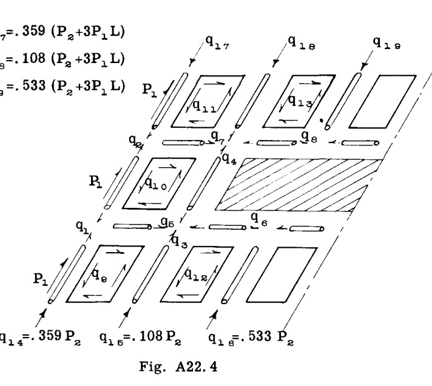

Fig. A22.4

経験によれば、対称的に荷重を受ける対称パネルの場合、横方向部材はその面内で剛体であるとみなして差し支えない（4）。したがって、この問題では、力 $q_5, q_6, q_7, q_8$ に対する部材の柔軟性はゼロとみなすことができる。比較対象となる実際のNACA試験片では、カットアウトに隣接する横方向部材は強力に補強されているように見えた（筆者にはその程度は不明である）。したがって、それらの剛性を非常に大きいとみなすことは論理的である。

部材柔軟性係数は、Chapter A7の公式を用いて、以下のようにマトリクス形式で収集された。下付き文字 5, 6, 7, 8 に対する係数はゼロ（剛な横方向部材）に設定されたことに注意されたい。

$$\alpha_{ij}, \text{ MEMBER FLEXIBILITY COEFFICIENTS } (E = 1)$$

(空白はゼロを示す)

| $i$ $j$ | 1 | 2 | 3 | 4 | 5 | 6 | 7 | 8 | 9 | 10 | 11 | 12 | 13 | 14 | 15 | 16 | 17 | 18 | 19 |
| --- | --- | --- | --- | --- | --- | --- | --- | --- | --- | --- | --- | --- | --- | --- | --- | --- | --- | --- | --- |
| 1 | 14.22 | 3.56 |  |  |  |  |  |  |  |  |  |  |  | -3.56 |  |  |  |  |  |
| 2 | 3.56 | 14.22 |  |  |  |  |  |  |  |  |  |  |  |  |  |  | -3.56 |  |  |
| 3 |  |  | 47.17 | 11.79 |  |  |  |  |  |  |  |  |  |  | -11.79 |  |  |  |  |
| 4 |  |  | 11.79 | 47.17 |  |  |  |  |  |  |  |  |  |  |  |  |  | -11.79 |  |
| 5 |  |  |  |  |  |  |  |  |  |  |  |  |  |  |  |  |  |  |  |
| 6 |  |  |  |  |  |  |  |  |  |  |  |  |  |  |  |  |  |  |  |
| 7 |  |  |  |  |  |  |  |  |  |  |  |  |  |  |  |  |  |  |  |
| 8 |  |  |  |  |  |  |  |  |  |  |  |  |  |  |  |  |  |  |  |
| 9 |  |  |  |  |  |  |  |  | 7.024 |  |  |  |  |  |  |  |  |  |  |
| 10 |  |  |  |  |  |  |  |  |  | 7.024 |  |  |  |  |  |  |  |  |  |
| 11 |  |  |  |  |  |  |  |  |  |  | 7.024 |  |  |  |  |  |  |  |  |
| 12 |  |  |  |  |  |  |  |  |  |  |  | 8.909 |  |  |  |  |  |  |  |
| 13 |  |  |  |  |  |  |  |  |  |  |  |  | 8.909 |  |  |  |  |  |  |
| 14 | -3.56 |  |  |  |  |  |  |  |  |  |  |  |  | 7.11 |  |  |  |  |  |
| 15 |  |  | -11.79 |  |  |  |  |  |  |  |  |  |  |  | 23.58 |  |  |  |  |
| 16 |  |  |  |  |  |  |  |  |  |  |  |  |  |  |  | 4.785 |  |  |  |
| 17 |  | -3.56 |  |  |  |  |  |  |  |  |  |  |  |  |  |  | 7.11 |  |  |
| 18 |  |  |  | -11.79 |  |  |  |  |  |  |  |  |  |  |  |  |  | 23.58 |  |
| 19 |  |  |  |  |  |  |  |  |  |  |  |  |  |  |  |  |  |  | 4.785 |

「対角線外」の値が負の符号を持つのは、下付き文字 (14), (15), (17), (18) を持つ内部一般化力の向きが、Art. A7.10の導出で使用されたものと反対に取られたためである。向きの変更は、対角線外係数の符号変更のみを必要とする。

$$\left[ g_{im} \vdots g_{ir} \right] =
\begin{array}{|c|c|c|c|c|}
\hline
\frac{m,r}{i} & 1 & 2 & 6 & 8 \\
\hline
1 & 4.755 & .316 & -1.68 & -.840 \\
2 & 9.510 & .316 & -.840 & -1.68 \\
3 & -19.76 & -1.316 & 1.68 & .840 \\
4 & -39.51 & -1.316 & .840 & 1.68 \\
5 & 0 & -.268 & 1.00 & 0 \\
6 & 0 & 0 & 1.00 & 0 \\
7 & -12.09 & -.268 & 0 & 1.00 \\
8 & 0 & 0 & 0 & 1.00 \\
9 & -1.317 & -.0450 & .112 & .056 \\
10 & -1.317 & 0 & -.056 & .056 \\
11 & .711 & .0450 & -.056 & -.112 \\
12 & 0 & .0355 & 0 & 0 \\
13 & -1.599 & -.0355 & 0 & 0 \\
14 & 0 & .359 & 0 & 0 \\
15 & 0 & .108 & 0 & 0 \\
16 & 0 & .533 & 0 & 0 \\
17 & 16.16 & .359 & 0 & 0 \\
18 & 4.86 & .108 & 0 & 0 \\
19 & 23.98 & .359 & 0 & 0 \\
\hline
\end{array}$$

以下のマトリクスが形成された。

Chapter A8の式(17)より：

$$\left[ \alpha_{rn} \right] = \left[ \begin{array}{cc} -5206 & -262.8 \\ -6633 & -262.8 \end{array} \right]$$

Chapter A8の式(18)より：

$$\left[ \alpha_{rs} \right] = \left[ \begin{array}{cc} 392.1 & 293.5 \\ 293.5 & 392.1 \end{array} \right]$$

この最後のマトリクスの逆行列は以下のように求められた。

$$\left[ \alpha_{rs}^{-1} \right] = 10^{-6} \left[ \begin{array}{cc} 5.802 & -4.343 \\ -4.343 & 5.802 \end{array} \right]$$

最後に、Chapter A8の式(23)により、単位荷重応力分布は次のようになった。

$$\left[ G_{im} \right] =
\begin{array}{|c|c|c|}
\hline
\frac{m}{i} & 1 & 2 \\
\hline
1 & -10.93 & -.65 \\
2 & -18.34 & -.65 \\
3 & -4.08 & -.351 \\
4 & -11.66 & -.351 \\
5 & 1.40 & .115 \\
6 & 1.40 & .383 \\
7 & 3.79 & .115 \\
8 & 15.88 & .383 \\
9 & -.270 & .019 \\
10 & -.510 & 0 \\
11 & -1.15 & -.019 \\
12 & 0 & .0355 \\
13 & -1.60 & -.0355 \\
14 & 0 & .359 \\
15 & 0 & .108 \\
16 & 0 & .533 \\
17 & 16.16 & .359 \\
18 & 4.86 & .108 \\
19 & 23.98 & .359 \\
\hline
\end{array}$$

上記の実用的結果は、荷重 $P_2 = 1, P_1 = 0$ に対する NACA 試験データ（1）と Fig. A22.5 で比較されている。一致は良好であることがわかる。

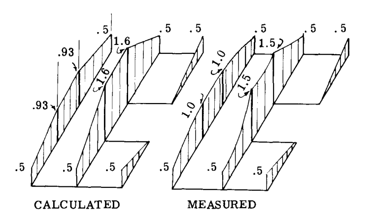

Fig. A22.5

### リブ柔軟性の影響：

リブの柔軟性の影響を調べるために、カットアウトに隣接する横方向部材として、一定面積 $A = .25 \text{ in}^2$ のアルミ製リブキャップを想定して問題を再加工した。適切な部材柔軟性係数は、上記で使用された $\alpha_{ij}$ マトリクス（上記のゼロの代わり）に挿入され、以下のようになった。

$$\left[ \alpha_{ij} \right] =
\begin{array}{|c|c|c|c|c|}
\hline
\frac{j}{i} & 5 & 6 & 7 & 8 \\
\hline
5 & 18.03 & 5.04 & & \\
6 & 5.04 & 10.08 & & \\
7 & & & 18.03 & 5.04 \\
8 & & & 5.04 & 10.08 \\
\hline
\end{array}$$

修正された $\left[ \alpha_{ij} \right]$ マトリクスを使用し、前と同じ手順を繰り返して問題を解き、以下の応力を得た。

$$\left[ G_{im} \right]_{\text{FLEXIBLE RIBS}} =
\begin{array}{|c|c|c|}
\hline
\frac{m}{i} & 1 & 2 \\
\hline
1 & -11.11 & -.621 \\
2 & -16.83 & -.621 \\
3 & -3.90 & -.379 \\
4 & -13.17 & -.379 \\
5 & 2.14 & .104 \\
6 & 2.14 & .372 \\
7 & 2.52 & .104 \\
8 & 14.61 & .372 \\
9 & -.26 & .017 \\
10 & -.62 & 0 \\
11 & -1.05 & -.017 \\
12 & 0 & .036 \\
13 & -1.60 & -.036 \\
14 & 0 & .359 \\
15 & 0 & .108 \\
16 & 0 & .533 \\
17 & 16.11 & .359 \\
18 & 4.86 & .108 \\
19 & 23.98 & .359 \\
\hline
\end{array}$$

## A22.3 ボックスビームのせん断遅れ（シアラグ）解析

「ボックスビームの曲げ応力は、必ずしも工学的曲げ理論の予測と非常に密接に一致するわけではない。理論からの逸脱は、主にビームのフランジを構成するボックスのカバーにおけるせん断変形によって引き起こされる。工学的曲げ理論からのこれらの逸脱を解析する問題は、せん断遅れ（シアラグ）問題として知られるようになり、この用語はあまり説明的ではないが便利である」(3)

Fig. A22.6 は基本的な問題を示している。ビームのカバーシートは、桁ウェブからのせん断流によって縁部に沿って荷重を受ける。これらのせん断流は、縦方向部材（桁縁材およびストリンガー）に発生する軸方向力によって抵抗される。初等的な考察によれば、ストリンガー応力は、任意のビームステーションにおいて弦方向に均一であるべきである（図の「初等理論」）。実際には、縁部から荷重を伝える中間シートがせん断に対して完全に剛ではないため、中央のストリンガーは荷重を受け取る際に他のストリンガーよりも「遅れる」傾向がある。

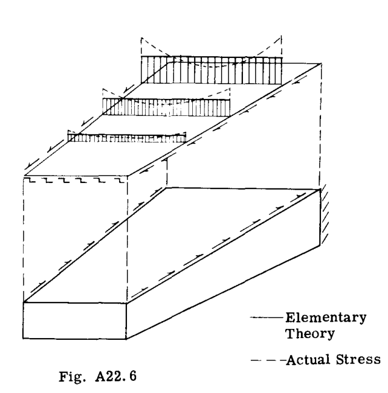

Fig. A22.6

この作用は、極端なケースを視覚化することで容易に理解できる。荷重を伝える外板がプラスチックシートやゴムなどの非常に柔軟な材料で作られている場合、大きな程度の「遅れ」が発生する。そのような場合、内側のストリンガーはほぼ完全に機能しなくなる。内側のストリンガー応力が遅れるため、外側のストリンガーと桁縁材は平衡を維持するために過剰な応力を負担しなければならない（図の「実際」）。

Fig. A22.7 は、ここで解析したビームを示している。

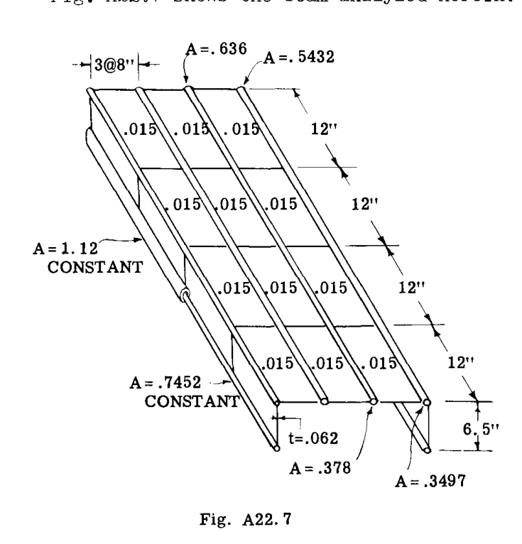

Fig. A22.7

このビームは、NACAによって試験され、参考文献（3）で報告されたものをモデル化したものである。ビームには下部カバーシートがなく、鉛直軸に対して対称であることに注意されたい。横方向の隔壁（バルクヘッド）は、固定部から 12“, 24”, 36“, 48” の位置にある。

実際のビーム試験片は、モデル化された構造に示されているよりも3本多いストリンガーを持っており、これらは Fig. A22.7 のビームカバーに示されている縦方向部材のペアの中間にそれぞれ1本ずつ配置されていた。モデル化プロセスにおいて、これらの余分なストリンガー面積は、隣接する縦方向部材に等しく分割された。示されているストリンガー面積は有効面積であり、上部カバーの面積は固定部から先端に向かって線形にテーパーしている。すべての外板は軸方向応力を負担するのに有効であるとみなされた。

実用的なビームのモデル化技術に関するいくつかの詳細な議論は、参考文献（5）および（5a）に示されている。

### 解法:

限られたスペースで計算を処理できるようにするため、対称的に配置された単一の横方向（垂直）先端荷重に対して構造を解析することを選択した。その場合、対称性のため、構造の半分だけを扱えば十分であった。さらに、中央のパネルにはせん断流が発生し得ない。さらに、せん断遅れに対するリブ柔軟性の影響は対称システムではわずかであることが知られているため、リブはその面内で剛であるとみなされ、したがって、それらのひずみエネルギーを記述するためにリブに一般化力を必要としなかった。

Fig. A22.8 は、半ビーム上の一般化力の配置と番号付けを示している。

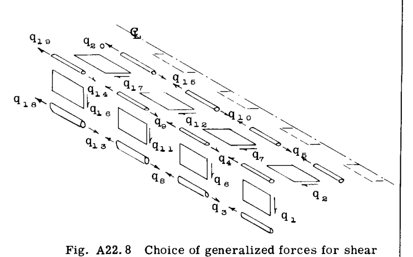

Fig. A22.8

部材柔軟性係数は、Chapter A7の公式を用いて計算され、マトリクスに配置された。

せん断流 $q_2, q_7, q_{12}$ および $q_{17}$ が不静定力として選択された。これらをゼロに設定すると、先端での0.5ポンドの荷重（ビームの半分に等しく分割された単位荷重）による応力分布が容易に計算された。

$$\left[ g_{im} \right] =
\begin{Bmatrix}
.07692 \\
0 \\
-.9230 \\
.9230 \\
0 \\
.07692 \\
0 \\
-1.8461 \\
1.8461 \\
0 \\
.07692 \\
0 \\
-2.769 \\
2.769 \\
0 \\
.07692 \\
0 \\
-3.692 \\
3.692 \\
0
\end{Bmatrix}$$

次に、単位不静定応力分布が計算された。Fig. A22.9 は、 $q_2 = 1, q_7 = q_{12} = q_{17} = 0$ に対する先端ベイの応力を示す代表的な計算を示している。

$$\alpha_{ij}, \text{ MEMBER FLEXIBILITY COEFFICIENTS } (E = 1)$$

| $i$ $j$ | 1 | 2 | 3 | 4 | 5 | 6 | 7 | 8 | 9 | 10 | 11 | 12 | 13 | 14 | 15 | 16 | 17 | 18 | 19 | 20 |
| --- | --- | --- | --- | --- | --- | --- | --- | --- | --- | --- | --- | --- | --- | --- | --- | --- | --- | --- | --- | --- |
| 1 | 3271 |  |  |  |  |  |  |  |  |  |  |  |  |  |  |  |  |  |  |  |
| 2 |  | 16,640 |  |  |  |  |  |  |  |  |  |  |  |  |  |  |  |  |  |  |
| 3 |  |  | 10.74 |  |  |  |  | 2.684 |  |  |  |  |  |  |  |  |  |  |  |  |
| 4 |  |  |  | 20.05 |  |  |  |  | 4.724 |  |  |  |  |  |  |  |  |  |  |  |
| 5 |  |  |  |  | 17.99 |  |  |  |  | 4.202 |  |  |  |  |  |  |  |  |  |  |
| 6 |  |  |  |  |  | 3271 |  |  |  |  |  |  |  |  |  |  |  |  |  |  |
| 7 |  |  |  |  |  |  | 16,640 |  |  |  |  |  |  |  |  |  |  |  |  |  |
| 8 |  |  | 2.684 |  |  |  |  | 8.939 |  |  |  |  | 1.785 |  |  |  |  |  |  |  |
| 9 |  |  |  | 4.724 |  |  |  |  | 17.84 |  |  |  |  | 4.255 |  |  |  |  |  |  |
| 10 |  |  |  |  | 4.202 |  |  |  |  | 15.78 |  |  |  |  | 3.708 |  |  |  |  |  |
| 11 |  |  |  |  |  |  |  |  |  |  | 3271 |  |  |  |  |  |  |  |  |  |
| 12 |  |  |  |  |  |  |  |  |  |  |  | 16,640 |  |  |  |  |  |  |  |  |
| 13 |  |  |  |  |  |  |  | 1.785 |  |  |  |  | 7.142 |  |  |  |  | 1.785 |  |  |
| 14 |  |  |  |  |  |  |  |  | 4.255 |  |  |  |  | 16.084 |  |  |  |  | 3.840 |  |
| 15 |  |  |  |  |  |  |  |  |  | 3.708 |  |  |  |  | 13.89 |  |  |  |  | 3.324 |
| 16 |  |  |  |  |  |  |  |  |  |  |  |  |  |  |  | 3271 |  |  |  |  |
| 17 |  |  |  |  |  |  |  |  |  |  |  |  |  |  |  |  | 16,640 |  |  |  |
| 18 |  |  |  |  |  |  |  |  |  |  |  |  | 1.785 |  |  |  |  | 3.571 |  |  |
| 19 |  |  |  |  |  |  |  |  |  |  |  |  |  | 3.840 |  |  |  |  | 7.518 |  |
| 20 |  |  |  |  |  |  |  |  |  |  |  |  |  |  | 3.324 |  |  |  |  | 6.439 |

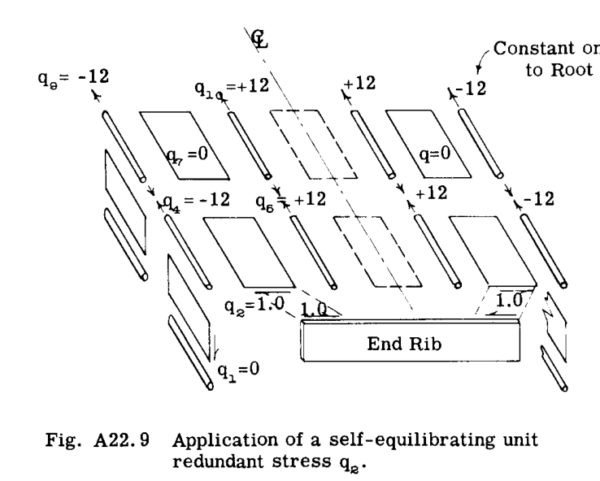

Fig. A22.9

完全な不静定応力は以下の通りであった：*

$$\left[ g_{ir} \right] =
\begin{array}{|c|c|c|c|c|}
\hline
r & 2 & 7 & 12 & 17 \\
\hline
1 & 0 & 0 & 0 & 0 \\
2 & 1 & 0 & 0 & 0 \\
3 & 0 & 0 & 0 & 0 \\
4 & -12 & 0 & 0 & 0 \\
5 & 12 & 0 & 0 & 0 \\
6 & 0 & 0 & 0 & 0 \\
7 & 0 & 1 & 0 & 0 \\
8 & 0 & 0 & 0 & 0 \\
9 & -12 & -12 & 0 & 0 \\
10 & 12 & 12 & 0 & 0 \\
11 & 0 & 0 & 0 & 0 \\
12 & 0 & 0 & 1 & 0 \\
13 & 0 & 0 & 0 & 0 \\
14 & -12 & -12 & -12 & 0 \\
15 & 12 & 12 & 12 & 0 \\
16 & 0 & 0 & 0 & 0 \\
17 & 0 & 0 & 0 & 1 \\
18 & 0 & 0 & 0 & 0 \\
19 & -12 & -12 & -12 & -12 \\
20 & 12 & 12 & 12 & 12 \\
\hline
\end{array}$$

- これは、構造的結合を減少させるために不静定力の組み合わせを使用する明白な場所である（Chapter A8, pp. A8.29, 30を参照）。（学生への演習として推奨される。）

以下のマトリクス積が形成された（Chapter A8の式(17), (18)による）：

$$\left[ \alpha_{rn} \right] = \begin{Bmatrix} -2175 \\ -1848 \\ -1260 \\ -460.7 \end{Bmatrix}$$

$$\left[ \alpha_{rs} \right] = \left[ \begin{array}{cccc} 40,210 & 16,810 & 9,536 & 3,041 \\ 16,810 & 32,160 & 9,536 & 3,041 \\ 9,536 & 9,536 & 25,030 & 3,041 \\ 3,041 & 3,041 & 3,041 & 18,650 \end{array} \right]$$

この最後のマトリクスの逆行列は以下のように求められた。

$$\left[ \alpha_{rs}^{-1} \right] = 10^{-6} \left[ \begin{array}{cccc} 3.285 & -1.505 & -.656 & -.183 \\ -1.505 & 4.219 & -1.000 & -.279 \\ -.656 & -1.000 & 4.687 & -.495 \\ -.183 & -.279 & -.495 & 5.519 \end{array} \right]$$

そして、最後に、Chapter A8の式(23)により、

$$\left[ G_{im} \right] =
\begin{Bmatrix}
.07692 \\
.03453 \\
-.9230 \\
.5086 \\
.4144 \\
.07692 \\
.03136 \\
-1.846 \\
1.055 \\
.7907 \\
.07692 \\
.02401 \\
-2.7691 \\
1.690 \\
1.079 \\
.07692 \\
.01005 \\
-3.692 \\
2.493 \\
1.199
\end{Bmatrix}$$

Fig. A22.10 は、上記の計算された応力と、試験によって得られたものとして NACA によって報告された応力を示している。一致は極めて良好であることがわかる。

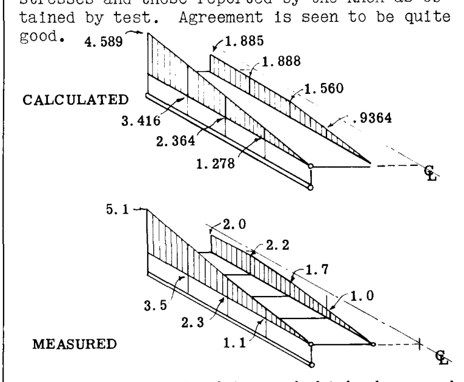

Fig. A22.10

## A22.4 カットアウトを持つボックスビームの応力解析

Art. A22.2 では、カットアウト周囲の応力を計算するために1つの技術が採用された。その解析では、カットアウトの影響はカットアウト領域付近に局所化されていると想定されたため、影響を受けるパネルを隔離することで問題が処理された。多くの場合、カットアウトが翼のかなり内側に配置されていると、ルート応力に対するその影響は無視できない。したがって、そのような場合には、カットアウトを持つボックスビームの全体的な問題を考慮できることが望ましい。

「カットアウトを持つ構造を解析する最も便利で迅速な方法は、間接法、または逆法である。間接法による解析は2つのステップで行われる。第一に、カットアウトが行われる前に存在する基本的な状態について構造が解析される。この基本解析の結果を用いて、提案されたカットアウトの境界に沿って存在する内部力を計算する。次に、これらの内部力と等しく反対方向の外力が導入される。これらの外力は、提案されたカットアウトの境界に沿って応力をゼロに減少させ、結果として、応力を乱すことなくカットアウトを行うことができるようになる」(3)*

前節（A22.3、「せん断遅れ解析」）の計算を修正して、対称的に配置された2つのカットアウトの存在を考慮することが望まれる。単一の先端荷重は残したまま、パネル " $q_{12}$ " が取り除かれた。ユニットは対称なままであるため、横方向リブ剛性を無限大とした前回の解析データは、依然として満足のいく結果を与えるはずである。

### 解法:

計算は3つのステップで達成された：

1. 「基本構造」（カットアウトなし）の応力分布が求められた。この作業は Art. A22.3 で行われ、そこでは $q_{12} = .02401 \text{ lbs./inch}$ であることがわかった。
2. $q_{12} = 1$ の「適用荷重」に対する応力分布が求められた。このような荷重は、外部の合力がゼロである。
3. この最後の応力分布の .02401 倍を最初から差し引いた。
- ここで説明する手順は、1つ以上の部材を取り除く影響を調べるために、一般的に非常に有用である。これは、構造的損傷の影響を解析するために必要とされる場合がある。

上記のステップ(2)の計算は、他のすべての荷重がゼロである間に、単位せん断流 $q_{12} = 1$ が適用されることを考慮して行われる。この荷重条件下では、不静定カット 2, 7, 17 における相対変位は、それぞれ $\alpha_{2,12}$ , $\alpha_{7,12}$ および $\alpha_{17,12}$ に等しく、これらの係数は Art. A22.3 で以前に計算されている。

連続性を回復する（相対変位をゼロに減少させる）ために、カット 2, 7, 17 にそれぞれ1つずつ、3つの不静定力が適用される。連続性を指定する適切な方程式は以下の通りである。

$$\left[ \begin{array}{ccc} \alpha_{2,2} & \alpha_{2,7} & \alpha_{2,17} \\ \alpha_{7,2} & \alpha_{7,7} & \alpha_{7,17} \\ \alpha_{17,2} & \alpha_{17,7} & \alpha_{17,17} \end{array} \right] \left\{ \begin{array}{c} q_2 \\ q_7 \\ q_{17} \end{array} \right\} = - \left\{ \begin{array}{c} \alpha_{2,12} \\ \alpha_{7,12} \\ \alpha_{17,12} \end{array} \right\}$$

これらの方程式は、単に、(未知の) 不静定力による不静定カットでのたわみが、 $q_{12} = 1$ によるたわみと等しく反対でなければならないことを示している。

上記方程式のすべての係数は Art. A22.3 で計算された。具体的には、

$$\left[ \begin{array}{ccc} 40,210 & 16,810 & 3,041 \\ 16,810 & 32,160 & 3,041 \\ 3,041 & 3,041 & 18,650 \end{array} \right] \left\{ \begin{array}{c} q_2 \\ q_7 \\ q_{17} \end{array} \right\} = - \left\{ \begin{array}{c} 9,536 \\ 9,536 \\ 3,041 \end{array} \right\}$$

上記のマトリクスは、Art. A22.3 の $\left[ \alpha_{rs} \right]$ から " $q_{12}$ 行" と " $q_{12}$ 列" を取り除いたものである。

方程式を解いて**、単位適用荷重 $q_{12} = 1$ に対する不静定力の値を得た：

$$\left\{ G_{S,12} \right\} = \left\{ \begin{array}{c} q_2 \\ q_7 \\ q_{12} \\ q_{17} \end{array} \right\} = \left\{ \begin{array}{c} -.1399 \\ -.2134 \\ 1.00 \\ -.1055 \end{array} \right\} q_{12} = 1$$

$q_{12}$ 力は、後で便利にするために上記に含まれている。そして、単位せん断流 $q_{12} = 1$ を適用することによる完全な応力分布は、以下のようになった。

** 完全な $\left[ \alpha_{rs} \right]$ マトリクスに対して以前に見出されたものから、このマトリクスの逆行列を「抽出」する方法については付録を参照。

$$\left\{ G_{i,12} \right\} = \left[ g_{ir} \right] \left\{ G_{r,12} \right\}$$

$$= \begin{Bmatrix} 0 \\ -.1399 \\ 0 \\ 1.679 \\ -1.679 \\ 0 \\ -.2134 \\ 0 \\ 4.240 \\ -4.240 \\ 0 \\ 1.00 \\ 0 \\ -7.760 \\ 7.760 \\ 0 \\ -.1055 \\ 0 \\ -6.494 \\ 6.494 \end{Bmatrix}$$

( $\left[ g_{ir} \right]$ は Art. A22.3 から取得)

カットアウトを持つ荷重ビームの応力を得るために、前述のように、Art. A22.3 の「基本」応力分布から、上記の応力の .02401 倍を差し引いた。

$$\left\{ G_{im} \right\}_{\text{CUTOUT}} = \left\{ G_{im} \right\}_{\text{BASIC}} - .02401 \left\{ G_{i,12} \right\} =
\begin{Bmatrix}
.07692 \\
.03789 \\
-.9230 \\
.4683 \\
.4547 \\
.07692 \\
.03648 \\
-1.8461 \\
.9536 \\
.8925 \\
.07692 \\
0 \\
-2.7691 \\
1.8763 \\
.8927 \\
.07692 \\
.01258 \\
-3.692 \\
2.649 \\
1.037
\end{Bmatrix}$$

$q_{12}$ がゼロになり、カットアウトパネルが「取り外される」可能性があることに注意されたい。

様々な外力（ $m = 1, 2, 3 \dots$ ）を受ける構造の場合、上記に対応するより一般的な方程式は、

$$\left[ G_{im} \right]_{\text{CUTOUT}} = \left[ G_{im} \right]_{\text{BASIC}} - \left\{ G_{i,12} \right\} \left\lfloor G_{12,m} \right\rfloor$$

ここで、行マトリクス $\left\lfloor G_{12,m} \right\rfloor$ は単に $\left[ G_{im} \right]_{\text{BASIC}}$ の “12行” である。

### 試験データとの比較：

参考文献（3）は、解析されたケースの試験データを報告しており、ストリンガー応力は Fig. A22.11 にプロットされている。

実際の試験片では、カットアウトを通過するストリンガーが切断されていたため、ステーション 12 および 24 での応力はゼロであった。しかし、Art. A22.3 で議論された（カットアウトなしのビームに対する）モデル化プロセスの間、このストリンガーの面積は一部がコーミングストリンガーに、一部が桁縁材に配置された。同様に、カットアウトによって不連続となったパネルの中央部からのいくつかの有効外板も、桁縁材とコーミングストリンガーに追加された。

したがって、ステーション 12 および 24 での応力を計算する際には、コーミングストリンガーと桁縁材の完全なモデル化された面積を使用すべきではない（力 $q_8, q_{10}, q_{14}, q_{16}$ によって生成される）。これらの面積を適切な減算によって減少させ、応力が計算され、Fig. A22.11 にプロットされている。試験データとの一致は極めて満足のいくものであることがわかる。

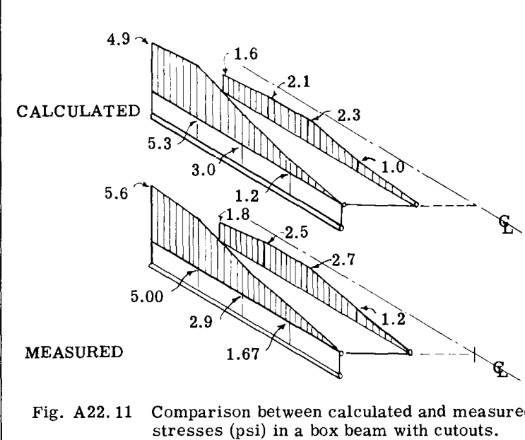

Fig. A22.11

## A22.5 後退ボックスビームの解析

「後退ボックスビームの実験的研究は、後退翼における応力と変形が、ルートが翼軸に対して垂直である場合に存在するであろうものとは著しく異なる性質を持ち得ることを示している。応力に対する後退の主な影響は、曲げ荷重の下で発生し、曲げ応力と垂直せん断力の集中から構成される。翼の後方桁付近の胴体近く。変形に関しては、後退の影響は、後退のない翼の曲げのみを生成する荷重の下でいくらかのねじれを生成し、後退のない翼のねじれのみを生成する荷重の下でいくらかの曲げを生成することである」(6)

以下の例では、後退ボックスビームが Chapter A8 のマトリクス法、特に参考文献（7）の特定の技術によって解析される。この方法は、後退カバーパネルと縦方向部材の間の相互作用を考慮している。後退ボックスビームの独特の構造特性を決定づけているのは、この作用である。

繰り返しになるが、ここで使用される方法は、梁のような比率の薄肉外板の翼にのみ厳密に適用可能であることを強調しておく。後退翼の構成で採用され得る多種多様な構造レイアウトを考慮すると、ここでは包括的な取り扱いを提供することはできない。厚肉外板構造や「プレートのような」（非常に薄く、幅の広い）翼により適した方法の優れたレビューは、参考文献（8）に記載されている。そのような翼を解析する1つの方法は、Chapter A23 に示されている。

### 構造：

Fig. A22.12 に示す構造は、参考文献（6）および（9）の NACA 試験ビームをモデル化したものであり、予想されるせん断遅れの影響を考慮するために、カバーシートに沿って単一の代替ストリンガーが採用されている。図は、飛行機の縦軸に対応する軸に対して対称に構築された完全なユニットの半分だけを示している。

先端荷重のみが適用される（点 A および B で）。ビームの外側セクションは、工学的曲げ理論（E.T.B.）によってかなり正確に計算できる応力を負担すると仮定された。この目的のために、ビームの外側 66" を単一のベイ（A-B-D-C）として考慮することで満足のいく結果が得られると判断された。もし荷重が先端よりも内側に適用される予定であったならば、A-B と C-D の間に追加のベイ分割を考慮する（すなわち、荷重適用のステーションに追加のリブを挿入する）ことが必要であったであろう。リブ C-D は、NACA 試験片の実際のリブ位置の1つに配置され、その面内で剛体であると仮定された。

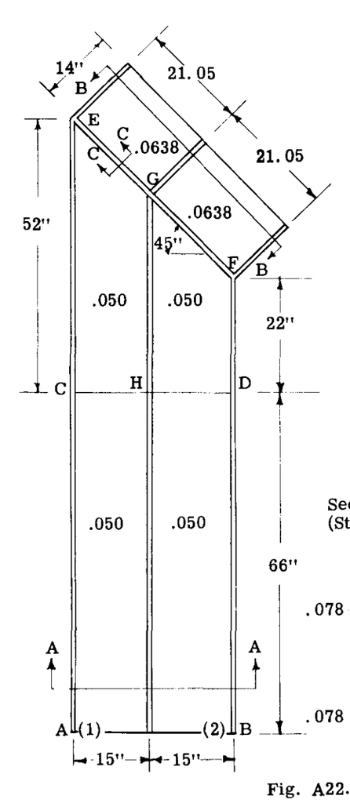

Fig. A22.12

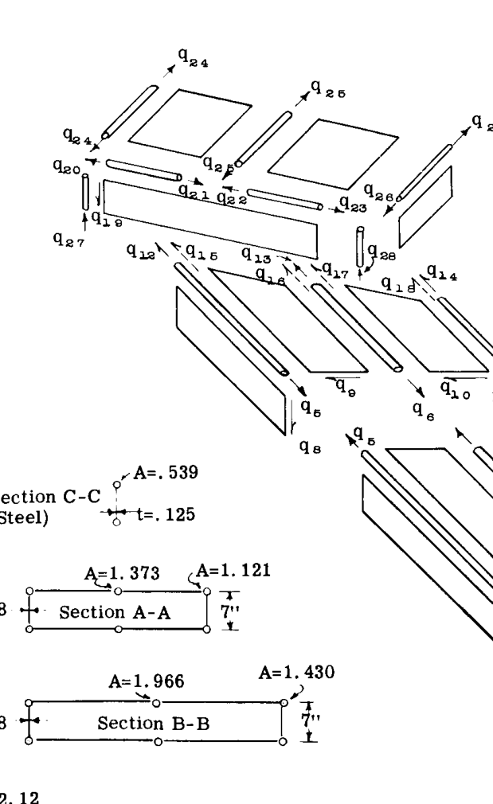

Fig. A22.13

シングルベイとしてのベイ C-D-F-E の選択は、やや任意であった。精度を向上させるために、C-D の内側に追加のリブを使用することもできた。点 F の内側に配置されたリブは、カバーシートに三角形の外板パネルを生成することに注意されたい。そのようなパネルの処理例は、参考文献（9）、（10）および（11）に記載されている。

リブ E-F は、その面内で柔軟であると考慮された。構造が方向を変える場所ではリブの柔軟性が重要であることが知られている。* 試験片では、このリブはスチール製であったことに注意されたい。

Fig. A22.12 に示す縦方向部材の有効面積は、外板のすべてが有効であると考慮して計算された。桁縁材面積は、縁材位置におけるアングル部材の面積に、縁材と代替ストリンガーの間の材料の有効面積の半分（この面積にはいくつかのストリンガーと外板が含まれる）を加え、さらに取り付けられた桁ウェブ面積の 1/6 を加えたものに等しい。** 代替ストリンガー面積は、両側の半パネルから同様の方法で収集された。

リブキャップ（E-F）の有効面積の計算に使用された方法は、参考文献（9）に詳細に記載されており、そこからここで使用された値が取得された。「キャリースルーベイ」のカバーシート厚さは、試験片で使用されたもの（.050"）に、対称面に沿ったスプライスプレートの存在を考慮するための加重増加を加えたものに等しい（参考文献9を参照）。

### 内部一般化力：

Fig. A22.13 は、一般化力の選択と番号付けを示している。

この解析では対称荷重のみが考慮されたため、キャリースルーベイによってせん断は伝達されず、したがってその部分にはせん断流は示されなかった。

- このリブの柔軟性を無視した場合の影響は、この例の後半で示される。

** 1/6 の係数は、ウェブの有効面積寄与により、オリジナルのものと同じ水平軸まわりの慣性モーメントを持つ構造が得られるように使用される。モデル化の問題のいくつかは、参考文献（2）、p.16 で議論されている。

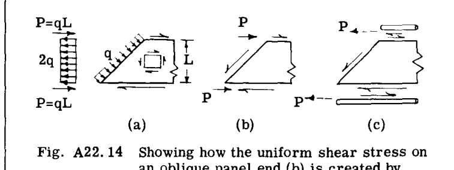

Fig. A22.14

エネルギーの観点から、これらの破線の力は、非矩形パネルにおけるせん断流の軸方向成分によって蓄えられる追加のひずみエネルギーを考慮している。このエネルギーは、カバーパネル自体に蓄えられ（縦方向部材がカバーシートからの有効面積を含んでいるため、この方法で考慮される***）、これらの成分に対して反作用する縦方向部材に蓄えられる。

「破線荷重」は、斜めにカットされたパネル端部に隣接する縦方向部材に適用される。同様の破線荷重は、斜めにカットされている場合、ベイ C-D-F-E のパネルの外側端部にも適用される。このようなパネル構成は、気流に平行なリブを持つ後退翼構造でよく発生する。より一般的な四辺形パネルの公式は、参考文献7に記載されている。

### 応力分布

ここで考慮される対称荷重の場合、外側ベイはE.T.B.によって静定であると仮定されたため、構造は2次不静定にすぎなかった。

#### E.T.B.による外側ベイの応力：

リブ C-D におけるフランジ応力（ $P_1 = 1$ および $P_2 = 1$ の両方に対して）

$$M = 66\text{"\#} \\
I = 88.57 \text{ in.}^4; \quad C = 3.5\text{"}$$

$$f_b = \frac{MC}{I} = 2.608 \text{ psi}$$

したがって、

$$q_5 = q_7 = 2.608 \times 1.121 = 2.924 \text{ lbs.}$$

$$q_6 = 2.608 \times 1.373 = 3.581 \text{ lbs.}$$

せん断中心における単位横方向荷重に対して（対称性のため、中点）

$$q_a = \frac{3.581}{2 \times 66} = .02713 \text{ lbs/in}$$

$$q_b = .02713 + \frac{2.924}{66} = .07143 \text{ lbs/in}$$

単位荷重は、トルク $T = 15 \text{ in.lbs}$ の適用により、両側に 15" シフトされた。重ね合わされた均一なせん断流は、

$$q = \frac{T}{2A} = \frac{15}{2 \times 210} = .03571 \text{ lbs/in}$$

最後に、重ね合わせにより、外側ベイの応力は次のようになった。

$$\left[ g_{im} \right] =
\begin{array}{|c|c|c|}
\hline
\frac{m}{1} & 1 & 2 \\
\hline
1 & .1071 & .03572 \\
2 & .06284 & -.00858 \\
3 & .00858 & -.06284 \\
4 & .03572 & .1071 \\
5 & 2.924 & 2.924 \\
6 & 3.581 & 3.581 \\
7 & 2.924 & 2.924 \\
\hline
\end{array}$$

*** このエネルギーの多くは、シートパネルの部材柔軟性係数を修正することにより、別の方法で考慮することができる。これが、参考文献12で行われた。しかし、その文献は、参考文献13で示されたように、縦方向部材に蓄えられる追加のエネルギーを誤って無視している。

#### 内側ベイの応力：

Chapter A8のArt. A8.12の議論によれば、静定応力分布 $\left[ g_{im} \right]$ は、適用荷重と平衡する任意の応力分布であってよく、好ましくは最終的な真の応力分布に近いものが望ましい。不静定力の大きさは、真の応力の満足のいく予測を使用することによって減少する。

2つの内側ベイの応力は、 $g_{im}$ と $g_{ir}$ の両方に対して同時に決定された。この内側部分は2次不静定であるため、2つの荷重を推定できる。この目的のために、2つのフランジ荷重 $q_{12}$ と $q_{14}$ は以下のように書かれた。

$$q_{12} = q'_{12} + q''_{12}$$

$$q_{14} = q'_{14} + q''_{14}$$

ここで、(単一の) プライム値は E.T.B. によって決定された近似値であり、ダブルプライム値は未知の修正（不静定力）である。先端から 66" および 118" のステーションで $My/I$ を使用すると、次のようになった。*

$$q'_{12} = 5.228 P_1 + 5.228 P_2$$

$$q'_{14} = 3.899 P_1 + 3.899 P_2$$

構造の要素に対する平衡方程式は、次に力とモーメントを合計することによって書かれた。

**ジョイント F**

$$q_{23} + q_{26} = 1.414 q_{14} = 5.513 P_1 + 5.513 P_2 + 1.414 q''_{14}$$

**ジョイント E**

$$q_{24} + q_{20} = 0$$

$$q_{24} - q_{20} = 1.414 q_{12} = 7.392 P_1 + 7.392 P_2 + 1.414 q''_{12}$$

**E-Fまわりの $\Sigma M$**

$$q_{24} + q_{25} + q_{26} = 11.918 P_1 + 8.888 P_2$$

- これは、これらの荷重を予測するかなり大雑把な方法であり、ここでは単純化のためだけに使用されている。解析者は一般に、他の後退翼の解法に導かれる程度であっても、これらの予測を行う際にもう少し独創性を発揮することが推奨される。

非矩形パネルの周囲のせん断流（E、G、Fのまわりのモーメントを合計して確認）。

**キャップ EC**

$$q_8 - .7115 q_9 = .04431 P_1 + .04431 P_2 + .01923 q''_{12}$$

**Eにおけるリブ垂直力**

$$q_8 - q_{19} = -.1403 P_1 - .2111 P_2$$

**キャップ EG**

$$-21.2 q_9 - 21.2 q_{19} - q_{20} + q_{21} = 0$$

**ジョイント G**

$$.707 q_{13} - q_{25} = 0$$

$$.707 q_{13} - q_{21} + q_{22} = 0$$

**キャップ GF**

$$q_{10} + q_{19} + .04717 (q_{22} - q_{23}) = 0$$

**Fにおけるリブ垂直力**

$$q_{11} + q_{19} = .2831 P_1 + .3540 P_2$$

**キャップ DF**

$$q_{11} + 1.682 q_{10} = .04432 (P_1 + P_2) + .04545 q''_{14}$$

上記の最初の5つの方程式は、代入によって容易に解かれ、以下が得られた：

$$q_{23} = q_{26} = 2.756 P_1 + 2.756 P_2 + .707 q''_{14}$$

$$-q_{20} = q_{24} = 3.696 P_1 + 3.696 P_2 + .707 q''_{12}$$

$$q_{25} = 5.466 P_1 + 2.436 P_2 - .707 q''_{12} - .707 q''_{14}$$

また、ジョイント G の平衡から：

$$q_{13} = 7.729 P_1 + 3.444 P_2 - q''_{12} - q''_{14}$$

残りの7つの方程式は、以下のように解くために配置された：

$$\left[ \begin{array}{ccccccc} 1 & 0 & 0 & 0 & -1 & 0 & 0 \\ 1 & -.7115 & 0 & 0 & 0 & 0 & 0 \\ 0 & 0 & 21.2 & 0 & 21.2 & 0 & 1 \\ 0 & 0 & 1.682 & 1 & 0 & 0 & 0 \\ 0 & 0 & 0 & 1 & 1 & 0 & 0 \\ 0 & -21.2 & 0 & 0 & -21.2 & 1 & 0 \\ 0 & 0 & 0 & 0 & 0 & -1 & 1 \end{array} \right] \left\{ \begin{array}{c} q_8 \\ q_9 \\ q_{10} \\ q_{11} \\ q_{19} \\ q_{21} \\ q_{22} \end{array} \right\} =$$

$$\left[ \begin{array}{cccc} -.1403 & -.2111 & 0 & 0 \\ .04431 & .04431 & .01923 & 0 \\ 2.756 & 2.756 & 0 & .707 \\ .04432 & .04432 & 0 & .04545 \\ .2831 & .3540 & 0 & 0 \\ -3.696 & -3.696 & -.707 & 0 \\ -5.466 & -2.436 & .707 & .707 \end{array} \right] \left\{ \begin{array}{c} P_1 \\ P_2 \\ q''_{12} \\ q''_{14} \end{array} \right\}$$

この最後の方程式の左辺の係数マトリクスを逆変換し、それによって乗算した後、応力は以下のように得られた。

$$\left\{ \begin{array}{c} q_8 \\ q_9 \\ q_{10} \\ q_{11} \\ q_{19} \\ q_{21} \\ q_{22} \end{array} \right\} = \left[ \begin{array}{cccc} .1006 & .0295 & .00676 & -.00676 \\ .0791 & -.0208 & -.01753 & -.00950 \\ .0013 & -.0411 & .00401 & .0230 \\ .0422 & .1135 & -.00675 & .00675 \\ .2409 & .2409 & .00676 & -.00676 \\ 3.087 & .964 & -.9355 & -.3444 \\ -2.379 & -1.473 & -.2284 & .3625 \end{array} \right] \left\{ \begin{array}{c} P_1 \\ P_2 \\ q''_{12} \\ q''_{14} \end{array} \right\}$$

この時点までの結果を使用した、完全な静定および単位不静定応力分布は、したがって以下の通りであった。

$$\left[ g_{im} \vdots g_{ir} \right] =
\begin{array}{|c|c|c|c|c|}
\hline
\frac{m,r}{i} & 1 & 2 & 12" & 14" \\
\hline
1 & .1071 & .03572 & 0 & 0 \\
2 & .06284 & -.00858 & 0 & 0 \\
3 & .00858 & -.06284 & 0 & 0 \\
4 & .03572 & .1071 & 0 & 0 \\
5 & 2.924 & 2.924 & 0 & 0 \\
6 & 3.581 & 3.581 & 0 & 0 \\
7 & 2.924 & 2.924 & 0 & 0 \\
8 & .1006 & .0295 & .00676 & -.00676 \\
9 & .0791 & -.0208 & -.01753 & -.00950 \\
10 & .0013 & -.0411 & .00401 & .0230 \\
11 & .0422 & .1135 & -.00675 & .00675 \\
12 & 5.228 & 5.228 & 1.0 & 0 \\
13 & 7.729 & 3.444 & -1.0 & -1.0 \\
14 & 3.899 & 3.899 & 0 & 1.0 \\
15 & -.989 & .260 & .2191 & .1188 \\
16 & -1.384 & .360 & .3068 & .1662 \\
17 & -.0146 & .460 & .0449 & -.2576 \\
18 & -.0244 & .773 & -.0754 & -.4324 \\
19 & .2409 & .2409 & .00676 & -.00676 \\
20 & -3.696 & -3.696 & -.707 & 0 \\
21 & 3.087 & .964 & -.9355 & -.3444 \\
22 & -2.379 & -1.473 & -.2284 & .3625 \\
23 & 2.756 & 2.756 & 0 & .707 \\
24 & 3.696 & 3.696 & .707 & 0 \\
25 & 5.466 & 2.436 & -.707 & -.707 \\
26 & 2.756 & 2.756 & 0 & .707 \\
\hline
\end{array}$$

### 破線荷重の計算：

上記のマトリクスにおいて、荷重 $q_{15}, q_{16}, q_{17}$ および $q_{18}$ は、参考文献7に示されている一般四辺形パネルの公式に従って、 $q_9$ および $q_{10}$ から得られた。平行側面のパネルに適用可能な方程式は以下の通りである。

$$P_C = \frac{d}{c + d} qL \times 2$$

$$P_D = \frac{c}{c + d} qL \times 2$$

$$\text{平衡荷重 (= 破線荷重)}$$

$$\text{参考文献7の公式}$$

パネル CEGH に対して： $c = 52.3"$ 、 $d = 73.5"$ 、 $c + d = 125.8"$ 、 $L = 15"$ 。したがって、

$$q_{15} = \text{" } P_D \text{ "} = 2 \times \frac{52.3}{125.8} \times 15 \times (-) q_9 = -12.5 q_9$$

$$= -.989 P_1 + .260 P_2 + .2191 q''_{12} + .1188 q''_{14}$$

$$q_{16} = \text{" } P_C \text{ "} = 2 \times \frac{73.5}{125.8} \times 15 \times (-) q_9 = -17.5 q_9$$

$$= -1.384 P_1 + .360 P_2 + .3068 q''_{12} + .1662 q''_{14}$$

同様に、パネル HGFD に対して：

$$q_{17} = -.0146 P_1 + .460 P_2 - .0449 q''_{12} - .2576 q''_{14}$$

$$q_{18} = -.0244 P_1 + .773 P_2 - .0754 q''_{12} - .4324 q''_{14}$$

以下のマトリクス積が形成された：  
(Chapter A8の式17, 18, 23を参照)

$$\left[ \alpha_{rn} \right] = \left[ \begin{array}{cc} 17.70 & 250.2 \\ -173.7 & -50.43 \end{array} \right]$$

$$\left[ \alpha_{rs} \right] = \left[ \begin{array}{cc} 114.5 & 42.96 \\ 42.96 & 83.54 \end{array} \right]$$

$$\left[ \alpha_{rs}^{-1} \right] = \left[ \begin{array}{cc} 0.01082 & -.005563 \\ -.005563 & 0.01483 \end{array} \right]$$

### 試験データとの比較：

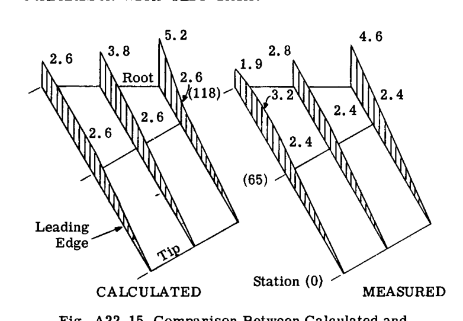

Fig. A22.15

Fig. A22.15 は、計算されたストリンガー応力と、参考文献6で報告されている NACA によって測定された応力との比較を示している。示されている応力は、中央に配置された単位先端荷重（ $P_1 = P_2 = 1/2 \text{ lb.}$ ）に対するものである。

分析の限界を考慮すると、一致は一般に満足のいくものである。したがって、ステーション 65 における $My/I$ 応力の不一致は、試験パラメータの正確な知識の欠如に起因する可能性がある。ステーション 65 と 118 の間の前縁桁における計算された応力は、モデル化においてこの領域に単一のベイしか採用されていなかったため、実験的な変動を再現することはできない。計算されたルート応力が一貫して試験値を上回っているという事実は、説明が難しい。計算された応力は平衡を満たしているため、すべて低い試験値はこの基本的な要件に反しているように思われる。試験技術とデータ提示方法に関するより詳細な情報は、おそらくこの矛盾を解決するであろう。試験値と計算値の両方が、後退翼の後方桁における応力の特徴的な蓄積を明確に示している。

### リブ E-G-F が剛体の場合：

興味深い事項として、リブ E-G-F が剛体であるとみなされた場合に応力に与える影響を調べることにした。このような計算は、リブの部材柔軟性係数をゼロに設定することによって容易に達成される。

したがって、マトリクス $\left[ \alpha_{ij} \right]$ において、下付き文字 19, 20, 21, 22 および 23 を持つそれらの係数はゼロに設定され、完全な計算が繰り返された。

翼根（最も敏感な点）における桁縁材荷重に対する結果は、以下の通りであった。

$$\left[ G_{im} \right]_{\text{RIGID RIB}} =
\begin{array}{|c|c|c|}
\hline
\frac{m}{1} & 1 & 2 \\
\hline
12 & 3.824 & 1.792 \\
14 & 6.993 & 6.610 \\
\hline
\end{array}$$

柔軟なリブの計算との比較は以下の通りである。

| 荷重 | 桁縁材力 | 柔軟リブ | 剛体リブ | ％差 |
| --- | --- | --- | --- | --- |
| 単純曲げ; $P_1 = P_2 = 1$ | $q_{12}$ $q_{14}$ | 6.311 12.61 | 5.616 13.60 | 11 8 |
| ねじり; $P_1 = -P_2 = 1$ | $q_{12}$ $q_{14}$ | 1.829 0.535 | 2.032 0.383 | 11 28 |

リブ EGF が元々比較的剛であったこと（厚手のスチールで作られているため）を考慮すると、対応するオールアルミ製のリブの柔軟性を無視すると、重大なエラーにつながる可能性があることがわかる。

## 参考文献

1. Kuhn, P., Duberg, J. E., and Diskin, J. H., Stresses Around Rectangular Cut-Outs in Skin-Stringer Panels Under Axial Load - II, NACA WR L368 (ARR 3J02), Oct. 1943
2. Rosecrans, R., A Method for Calculating Stresses in Torsion-Box Covers with Cut-outs, NACA TN 2290, Feb. 1951
3. Kuhn, P., and Chiarito, P. T., Shear Lag in Box Beams: Methods of Analysis and Experimental Investigations, NACA TR 739, 1942
4. Hoff, N. J., and Libby, P. A., Recommendations for Numerical Solutions of Reinforced Panel and Fuselage-Ring Problems, NACA TR 934, 1949
5. Kuhn, P., Approximate Stress Analysis of Multi-Stringer Beams with Shear Deformation of the Flanges, NACA TR 636, 1938

(5a) Kuhn, P., Deformation Analysis of Wing Structures, NACA TN 1361, July 1947

6. Zender, G., and Libove, C., Stress and Distortion Measurements in a 45° Swept Box Beam Subjected to Bending and Torsion, NACA TN 1525
7. Wehle, L. B., and Lansing, W., A Method for Reducing the Analysis of Complex Redundant Structures to a Routine Procedure, Journal of Aero. Sci., 19, Oct. 1952
8. Williams, M. L., A Review of Certain Analysis Methods for Swept Wing Structures, Journ. of Aero. Sci., 19, p. 615, 1952
9. Heldenfels, R., Zender, G., and Libove, C., Stress and Distortion Analysis of a Swept Box Beam Having Bulkheads Perpendicular to the Spars, NACA TN 2232.
10. Bisplinghoff, R., and Lang, A., An Investigation of Deformations and Stresses in Sweptback and Tapered Wings with Discontinuities, Mass. Inst. of Tech. Rept., July, 1949 (See also, Journ. of Aero. Sci. 18, p. 705, 1951)
11. Denke, P., The Matric Solution of Certain Non-Linear Problems in Structural Analysis, Journ. of Aero. Sci., 23, 1956
12. Levy, S., Computation of Influence Coefficients for Aircraft Structures with Discontinuities and Sweepback, Journ. of Aero. Sci., 14, Oct. 1947
13. Islinger, J. S., Stress Analysis and Stress Measurements for a Swept Back Wing Having Ribs Parallel to the Airstream, McDonnell Aircraft Corp. Report 1127, April 1949.